# Economic Data 2024 - Labs

Week 8

*Aims*: Data cleaning, applying functions by groups, libraries and data formats.

Your country depends on the timing of your lab session:

- Group 1: Tuesday 9:00 to 11:00: Greece
- Group 2: Tuesday 11:00 to 13:00: Finland
- Group 3: Tuesday 16:00 to 18:00: Spain
- Group 4: Wednesday 09:00 to 11:00: Slovenia
- Group 5: Wednesday 11:00 to 13:00: France

## Part 1

In this exercise, we will continue working on exchange rate data for your assigned country. You can consider the exchange rate against the US dollar which is made available by the [IMF](https://www.imf.org/external/np/fin/ert/GUI/Pages/CountryDataBase.aspx). To solve the exercise, go through the following steps.

- Download the data and clean the dataset. **Hint**: Do you need to skip lines to access the column names? What is the separator between variables in your data? Try using `read_table` instead of `read_csv`.
- Calculate the change in the natural logarithm of the exchange rate. Include this as a column in your dataset. What does $\Delta e_t$ approximate? **Hint**: The [following](https://sebastianellingsen.github.io/economic_data_course/lectures/lecture_2.html#6) derivation might be helpful.
  $$\begin{equation}
  \Delta e_t = 100\times \left(\log(E_t) - \log(E_{t-1}) \right)
  \end{equation}$$
- Reproduce the below plots for your assigned country.
- Why did you choose this period?
- What is measured by the exchange rate?
- For what day did the exchange rate depreciate the most?
- For what day did the exchange rate appreciate the most?
- Which time series below are stationary? Which are non-stationary?

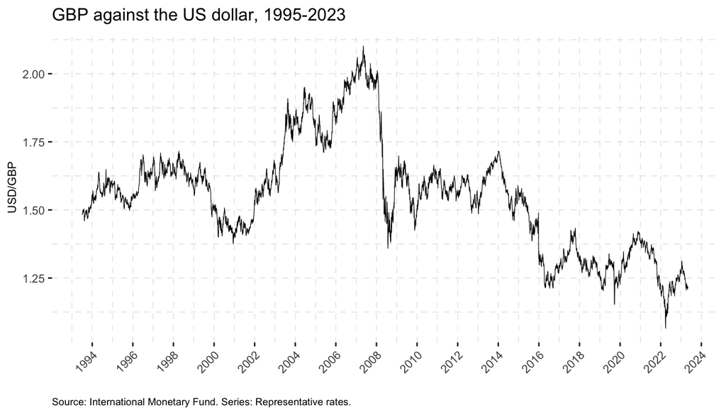

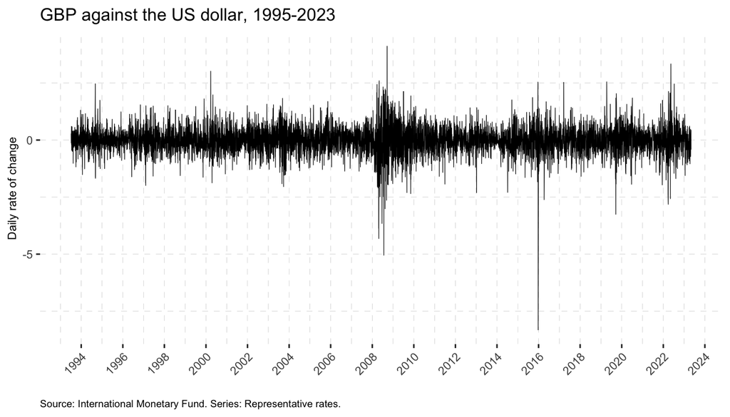

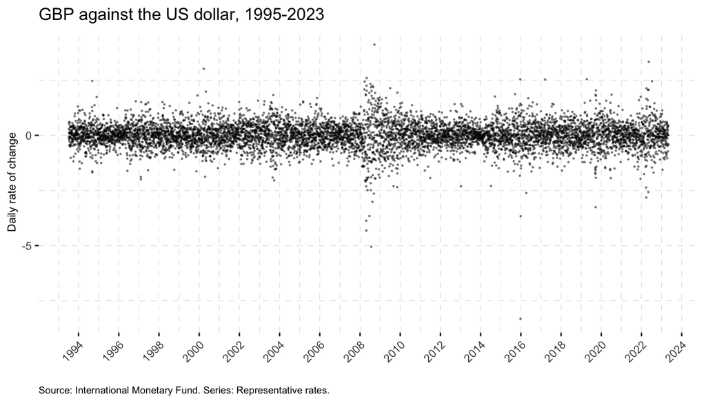

## Part 2

In this exercise, we will continue working on the fourth mini project which is available on Blackboard.